# Milestone 3

Author

Group 8: Erin Curlee, Val Stacey, Ana Terzo

Published

November 11, 2025

Preparing Data for Analysis

## Aligning Column Names

We first ensured that all column names referring to the same variables were consistent across the three databases, using the provided codebook as a reference. Standardizing these names improved both the efficiency of subsequent analyses and the clarity of the data dictionary developed later in this report.

To facilitate merging, we added a county field to the Los Angeles County database so that both datasets share the same set of columns, allowing them to be joined or appended to create a single statewide morbidity dataset for later analyses.

```r
##-- California dataset
ca_df <- raw_ca_df %>% select(-dt_diagnosis) %>%
  mutate(county = clean(county) %>%
          str_remove("\\s*[Cc]ounty$") %>%
          str_trim())

##-- LA county dataset
la_cnty_df <- raw_la_cnty_df %>%
  rename("age_cat" = "age_category",
        "race_ethnicity" = "race_eth",
        "new_infections" = "dx_new",
        "cumulative_infected" = "infected_cumulative",
        "new_unrecovered" = "unrecovered_new",
        "cumulative_unrecovered" = "unrecovered_cumulative",
        "new_severe" = "severe_new",
        "cumulative_severe" = "severe_cumulative") %>%
  mutate(county = "Los Angeles") %>%
  relocate(county, .before = everything())

##-- Population dataset
pop_df <- raw_pop_df %>%
  rename("race_ethnicity" = "race7") %>%
  mutate(county = clean(county))
```

### Figure 1. Reconciling Column Names

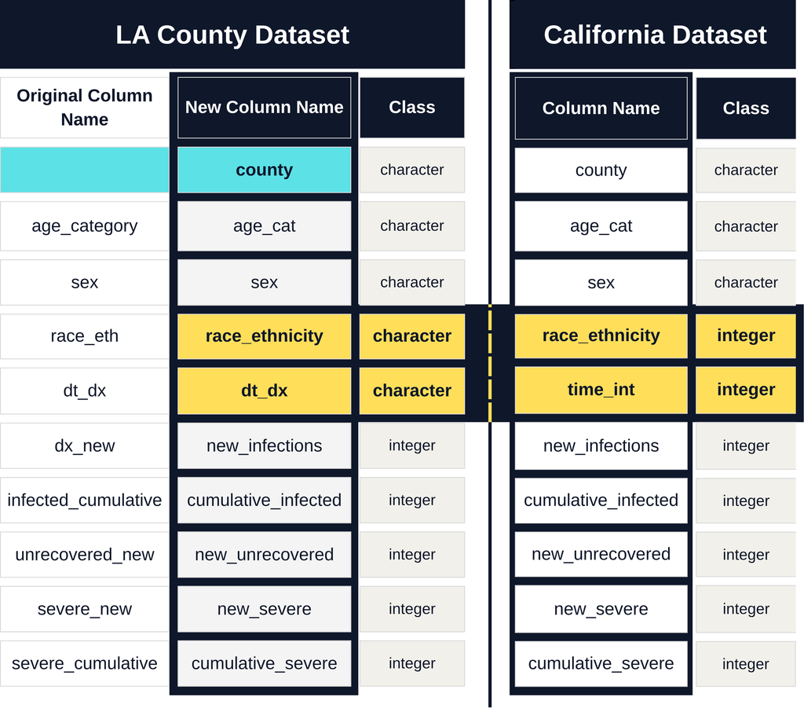

## Restructuring Variables

### Age Groups

The population database contains counts for six age groups, whereas the California and LA County databases use four. Because the groupings align — “0–4,” “5–11,” and “12–17” in the population database correspond to the “0–17” group in the others — we summarized the population counts to match the four age-group format.

In the original population database, counts are reported for each single year of age within every demographic subgroup (e.g., county, sex, race/ethnicity). To obtain total estimates per age group and demographic category, the single-year counts were aggregated (summed). **Table 1** below presents a subset of the original and restructured population data to illustrate the resulting summarized age groupings.

```r
pop_df <- pop_df %>%
  group_by(county, health_officer_region,
           sex, race_ethnicity, age_cat) %>%
  summarise(pop = sum(pop), .groups = "drop")

pop_df_recat <- pop_df %>%
  mutate(new_age_group =
          if_else(age_cat %in%
              c("0-4", "5-11", "12-17"),
              "0-17", age_cat)) %>%
  group_by(county, health_officer_region, sex,
           race_ethnicity, new_age_group) %>%
  summarise(pop = sum(pop), .groups = "drop") %>%
  rename("age_cat" = "new_age_group")
```

### Table 1: Reconciling Age Group Categories and Population Counts

**Original Age Groups:**

| County | Sex | Race / Ethnicity | Age Group | Population |
| --- | --- | --- | --- | --- |
| Alameda | FEMALE | Hispanic | 0-4 | 11587 |
| Alameda | FEMALE | Hispanic | 12-17 | 17098 |
| Alameda | FEMALE | Hispanic | 5-11 | 17761 |
| Total | - | - | - | 46,446 |

**New, Aggregate Age Group:**

| County | Sex | Race / Ethnicity | Age Group | Population |
| --- | --- | --- | --- | --- |
| Alameda | FEMALE | Hispanic | 0-17 | 46,446 |

### Infection Dates

To support date-based analyses, infection records will be aggregated by **MMWR week and year**. For both the Los Angeles County and California datasets, we will generate two new columns: **mmwr_year** and **mmwr_week**, then remove the original date-based fields. We will also add columns **start_date** and **end_date** to serve as reference points should we need them later.

In the California dataset, the field **time_int** encodes the year and MMWR week as a six-digit integer (YYYYWW). To create the new fields, we extract the first four digits as mmwr_year and the last two digits as mmwr_week, then drop the original time_int column.

In the Los Angeles County dataset, the codebook identifies a field **dt_report** as the last day of the MMWR week. However, this field contained only missing values, so it was removed. Instead, we convert the infection date field, **dt_dx** to a proper date format, and then use the `MMWRweek` package to derive the mmwr_year and mmwr_week.

```r
la_cnty_df <- la_cnty_df %>%
##--restructure to proper date format
mutate(DATE_FIX =
  as.Date(parse_date_time(dt_dx, "%d%b%Y"),
          format = "%Y-%m-%d")) %>%
##--use date to create new MMWR fields
add_mmwr_week_columns(date_col = "DATE_FIX") %>%
add_start_end_dates() %>%
select(-c(DATE_FIX, dt_dx)) %>%
relocate(mmwr_year, mmwr_week, start_date,
         end_date, .before = everything()) %>%
relocate(county, .before = age_cat)

ca_df <- ca_df %>%
##--pull MMWR week and year from time_int field
mutate(
  mmwr_year = factor(time_int %/% 100),
  mmwr_week = factor(time_int %% 100)) %>%
add_start_end_dates() %>%
select(-time_int) %>%
relocate(mmwr_year, mmwr_week, start_date,
         end_date, .before = everything())
```

To streamline this process, we created two helper functions:

- `add_mmwr_week_columns()` : takes date column and adds two fields: mmwr_year and mmwr_week
- `add_start_end_dates()` : uses those values to generate corresponding MMWR week start and end dates

**The dataframes now have a structure that looks like this:**

| mmwr_year | mmwr_week | start_date | end_date | county | age_cat | new_infections |
| --- | --- | --- | --- | --- | --- | --- |
| 2023 | 22 | 2023-05-28 | 2023-06-03 | Los Angeles | 0-17 | 15 |
| 2023 | 23 | 2023-06-04 | 2023-06-10 | Los Angeles | 0-17 | 17 |
| 2023 | 24 | 2023-06-11 | 2023-06-17 | Los Angeles | 0-17 | 23 |

## Race and Ethnicity:

Each of the three datasets defines Race / Ethnicity differently. The California dataset uses numeric codes, the Los Angeles County dataset uses full text labels, and the population dataset uses abbreviated text.

To resolve this, we created a crosswalk file (**race_ethnicity_map.csv**) that aligns the three formats. By joining this crosswalk to each dataset, we ensure that all three contain a consistent set of race and ethnicity variables: each with the numeric code, the abbreviated text, and the full text label.

```r
ca_df <- ca_df %>%
  rename("race_coded" = "race_ethnicity") %>%
  mutate(race_coded = as.character(race_coded)) %>%
  left_join(race_ethnicity_map, by = "race_coded")%>%
  relocate(race_coded, race_short, race_long, .after = sex)

la_cnty_df <- la_cnty_df %>%
  mutate(race_long = clean(race_ethnicity)) %>%
  select(-race_ethnicity) %>%
  left_join(race_ethnicity_map, by = "race_long") %>%
  relocate(race_coded, race_short, race_long, .after = sex)
```

### Race and Ethnicity Crosswalk Table:

| race_coded | race_long | race_short |
| --- | --- | --- |
| 1 | White, Non-Hispanic | WhiteTE NH |
| 2 | Black, Non-Hispanic | Black NH |
| 3 | American Indian or Alaska Native, Non-Hispanic | AIAN NH |
| 4 | Asian, Non-Hispanic | Asian NH |
| 5 | Native Hawaiian or Pacific Islander, Non-Hispanic | NHPI NH |
| 6 | Multiracial (two or more of above races), Non-Hispanic | MR NH |
| 7 | Hispanic (any race) | Hispanic |
| 9 | Unknown | Unknown |

## Population Counts by Demographic

To calculate infection rates by demographic groups (such as county, health officer region, sex, or race/ethnicity), we first summarize total population counts for each demographic category within the population dataframe. The population dataset is then joined to both the master database (which merges all three datasets) and the individual California and Los Angeles datasets.

By creating and maintaining these summarized population counts, we avoid having to recalculate them each time we focus on a different demographic group. For example, once this population dataset is joined to the California data, we can easily calculate population-adjusted infection rates that allow valid comparisons across counties with differing population sizes.

```r
pop_df <- pop_df_recat %>%

##-- join population database to the race/ethnicity map
  mutate(race_short = clean(race_ethnicity)) %>%
  select(-race_ethnicity) %>%
  left_join(race_ethnicity_map, by = "race_short") %>%
  relocate(race_coded, race_short, race_long, .after = sex) %>%

##-- calculate population totals by demographic
  group_by(county, health_officer_region) %>%
    mutate(total_cnty_pop = sum(pop)) %>% ungroup() %>%
  group_by(county, health_officer_region, race_coded, race_short, race_long) %>%
    mutate(total_race_pop = sum(pop)) %>% ungroup() %>%
  group_by(county, health_officer_region, sex) %>%
    mutate(total_sex_pop = sum(pop)) %>% ungroup() %>%
  group_by(health_officer_region) %>%
    mutate(total_HOR_pop = sum(pop)) %>% ungroup()
```

### Table 2: Calculating Infection Rate by 100,000 Population Example

[output not shown]

## Final Combined Database

After reconciling all column names across the 3 datasets, standardizing age group, race/ethnicity, and infection date variables, we merge them together to generate a final, complete database and begin our descriptive explorations and analyses.

```r
combined_df <- rbind(ca_df, la_cnty_df) %>%
  relocate(health_officer_region,  .after = county) %>%
  relocate(pop, .after = race_long) %>%
  mutate(age_cat = factor(age_cat, levels = c("0-17", "18-49", "50-64", "65+")))
```

```r
# final cleaned dataframes stored in "_data/cleaned_data/" directory

#--write.csv(combined_df, file = here("_data/cleaned_data/combined_df.csv"), row.names = FALSE)
#--write.csv(ca_df, file = here("_data/cleaned_data/cleaned_ca_df.csv"), row.names = FALSE)
#--write.csv(la_cnty_df, file = here("_data/cleaned_data/cleaned_la_cnty_df.csv"), row.names = FALSE)
#--write.csv(pop_df, file = here("_data/cleaned_data/cleaned_pop_df.csv"), row.names = FALSE)
```

Final Data Dictionary

[output not shown]

Descriptive Statistics

## Descriptive Statistics: Morbidity Datasets

```r
# Bring in final combined database
##-- CA + LA + Population
df <- read.csv(file = here("_data/cleaned_data/combined_df.csv"))

##-- final individual, cleaned databases:
ca_df <- read.csv(file = here("_data/cleaned_data/cleaned_ca_df.csv"))
la_cnty_df <- read.csv(file = here("_data/cleaned_data/cleaned_la_cnty_df.csv"))
pop_df <- read.csv(file = here("_data/cleaned_data/cleaned_pop_df.csv"))
```

to do:

- Overall descriptive stats:
  - infections by age group / county / region / race/ethnicity
  - severe infections by age group / county / region / race/ethnicity
  - unrecovered infections by age group / county / region / race/ethnicity
  - infections/severe infections/unrecovered infections by MMWR week
  - infections/severe infections/unrecovered infections by MMWR week / county or region
- Create a rate metric and summarize to include only one row per strata of interest
  - age-adjusted rates - compare AAR across county / region
  - Incidence rate / densities by age group and month?
  - Incidence rate / densities by race/ethnicity and month?
- Aggregate the data into a new dataframe(s) to include only one row per strata of interest

## Calculating Crude Rates

see functions found in: “_functions/calc_total_rates_pop.R”

### Infection Rates by Health Officer Region

| health_officer_region | total_pop | inf_rate_100k | sev_rate_100k | unrec_rate_100k |
| --- | --- | --- | --- | --- |
| Greater Sierra Sacramento | 2973210 | 1184.0 | 72.3 | 303.1 |
| Los Angeles | 9825708 | 1402.5 | 41.3 | 172.2 |
| Rural North | 683715 | 434.2 | 31.4 | 129.9 |
| Central California | 4432134 | 902.8 | 23.8 | 100.2 |
| Southern California | 12802429 | 626.2 | 17.3 | 73.4 |
| Bay Area | 8391874 | 189.5 | 11.4 | 48.2 |

```r
by_HOR_week <-
  counts_week_groups(
      df = df, mmwr_year, mmwr_week,
      health_officer_region
  )

by_HOR_pop <-
  calc_total_rates_pop(
      df = df, pop_col = total_HOR_pop,
      health_officer_region
  )
```

### Top 10 Highest Severe Infection Rates by County

| county | total_pop | inf_rate_100k | sev_rate_100k | unrec_rate_100k |
| --- | --- | --- | --- | --- |
| Inyo | 18731 | 4623.4 | 427.1 | 1590.9 |
| Imperial | 179639 | 10494.4 | 338.5 | 1364.4 |
| Sierra | 3152 | 2918.8 | 317.3 | 1269.0 |
| Alpine | 1165 | 2145.9 | 257.5 | 1373.4 |
| Tehama | 64677 | 3110.8 | 218.0 | 926.1 |
| Plumas | 18955 | 3001.8 | 211.0 | 933.8 |
| Calaveras | 44605 | 2475.1 | 190.6 | 784.7 |
| Mariposa | 16860 | 2437.7 | 189.8 | 806.6 |
| Modoc | 8446 | 2439.0 | 189.4 | 923.5 |
| San Luis Obispo | 280251 | 2158.8 | 173.4 | 707.6 |

```r
by_cnty_week <-
  counts_week_groups(
      df = df, mmwr_year, mmwr_week,
      county, health_officer_region
  )

by_cnty_pop <-
  calc_total_rates_pop(
      df = df, pop_col = total_cnty_pop,
      health_officer_region, county
  ) %>% arrange(health_officer_region, county)
```

### By Sex

- initial note: males have higher infection rate; but females have higher rates of severe infections and unrecovered

| sex | total_pop | inf_rate_100k | sev_rate_100k | unrec_rate_100k |
| --- | --- | --- | --- | --- |
| FEMALE | 849329 | 15316.8 | 478.0 | 1992.2 |
| MALE | 806708 | 17082.3 | 419.6 | 1784.0 |

```r
by_sex_cnty <-
  calc_total_rates_pop(
      df = df, pop_col = total_sex_pop,
      health_officer_region, county, sex
  ) %>% arrange(health_officer_region, county, sex)

by_sex_total <-
  calc_total_rates_pop(
      df = df, pop_col = total_sex_pop, sex
  )
```

### By Race and Ethnicity

- initial note: Hispanic population has highest infection rate, severe infection rate, and unrecovered rate – all across the board – this community is being impacted the most.

| race_long | total_pop | inf_rate_100k | sev_rate_100k | unrec_rate_100k |
| --- | --- | --- | --- | --- |
| Hispanic (any race) | 335452 | 41080.1 | 1015.3 | 4295.7 |
| White, Non-Hispanic | 485940 | 11033.5 | 835.5 | 3481.9 |
| American Indian or Alaska Native, Non-Hispanic | 4569 | 11775.0 | 744.1 | 2626.4 |
| Black, Non-Hispanic | 157817 | 11989.2 | 621.0 | 2577.0 |
| Asian, Non-Hispanic | 568612 | 5079.7 | 345.9 | 1400.1 |
| Native Hawaiian or Pacific Islander, Non-Hispanic | 14710 | 6233.9 | 163.2 | 666.2 |
| Multiracial (two or more of above races), Non-Hispanic | 88937 | 6127.9 | 133.8 | 579.1 |

```r
by_race_cnty <-
  calc_total_rates_pop(
      df = df, pop_col = total_race_pop,
      health_officer_region, county, race_long) %>%
  arrange(health_officer_region, county, race_long)


by_race_total <-
  calc_total_rates_pop(df = df, pop_col = total_race_pop, race_long)
```